# social_network_analysis

Fan Ouyang

August 22, 2017

## An exampler of social network analysis with two different dataset format

### 1.adjacency matrix (wide-format)

The first format is adjacency matrix (refer to http://faculty.ucr.edu/~hanneman/nettext/C5_%20Matrices.html for more details). This format can be considered as wide-format (in contrast with long-format, which will be discussed as the second format) #### one-mode network analysis It is usually used in one-mode network analysis (e.g. learner-learner interaction network). In this example, I use edge width to show degree(indegree and outdegree), and color to show students and the instructor

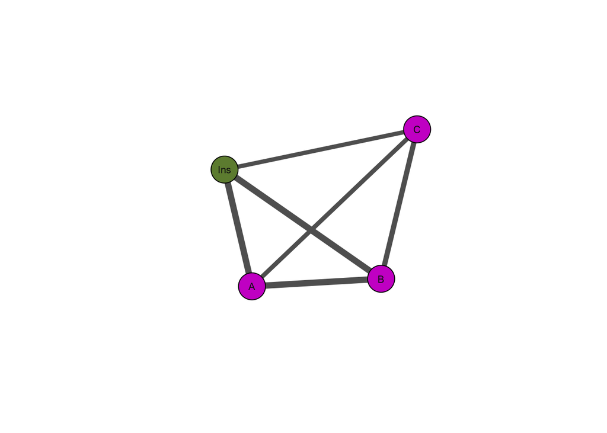

```r
require(sna)
# read data in
one_mode_mat<- as.matrix(read.csv("one_mode_ad_mat.csv", row.names=1))
colnames(one_mode_mat)=c("A","B","C","Ins")
rownames(one_mode_mat)=c("A","B","C","Ins")
# calculate degree
id<-degree(one_mode_mat,gmode="digraph",cmode="indegree")
od<-degree(one_mode_mat,gmode="digraph",cmode="outdegree")
# create color vector to show different colors for student and instructor
stu <- rep("magenta3", 3)
ins <- rep("darkolivegreen4", 1) # final one is the instructor
color <- c(stu, ins)
# plot one-mode network graph
gplot(one_mode_mat, gmode="graph", displaylabels=TRUE,
      label.cex = 0.7, label.col = "gray8", label.pos = 5,
      vertex.cex=2, vertex.col = color,
      edge.col = "gray38", edge.lwd=(id+od)/3)
```

#### two-mode network analysis

Adjacency matrix can also be used in two-mode network analysis. Here is another example of using adjacency matrix to create learner-activity participation network. In this example, I use color and shape to separately show people and activities and edge width to show a people’s participation frequency in an activity

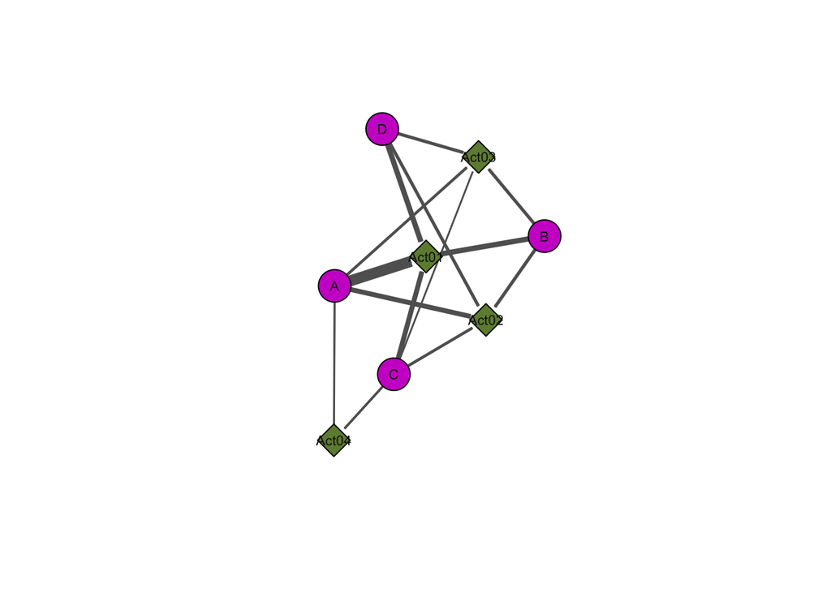

```r
require(sna)
two_mode_mat<- as.matrix(read.csv("two_mode_ad_mat.csv",row.names=1))
# create edge vector, saving participation frequency
edge<-c(two_mode_mat[,1],two_mode_mat[,2],two_mode_mat[,3],two_mode_mat[,4])
# create color vector to show different colors for people and activities
people <- rep("magenta3", 4)
activity <- rep("darkolivegreen4", 4)
color <- c(people, activity)
# plot two-mode network graph
gplot(two_mode_mat, gmode = "twomode", usearrows = F, displaylabels = T,
      label.cex = 0.7, label.col = "gray8", label.pos = 5,
      vertex.col = color, vertex.cex = 2,
      edge.col = "gray38", edge.lwd=edge/2,
      mode="fruchtermanreingold")
```

### 2.edgelist format (long-format)

#### one-mode(or two-mode) network analysis

Like the way adjacency matrix is used for one-mode and two-mode network analysis, edgelist format can also be used for both one-mode and two-mode network analysis

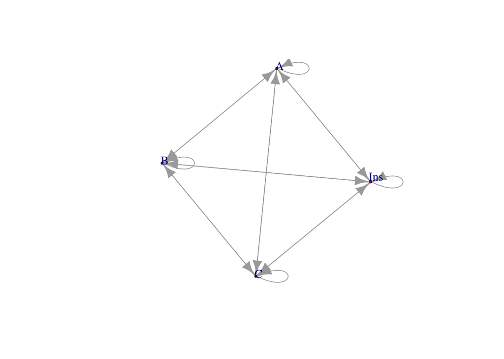

```r
require(reshape2)
require(igraph)
# convert wide-format matrix to long-format edgelist by using melt function
one_mode_ed=melt(one_mode_mat)
# convert edgelist to igraph format
one_mode_graph=graph.data.frame(one_mode_ed)
#plot with igraph, please refer to http://igraph.org/r/doc/plot.common.html for more details
plot(one_mode_graph,vertex.size=2,
     vertex.label.dist=0.5, vertex.color="red")
```

#### I prefer to use sna package for network graph demonstration, so I convert igraph into matrix or network

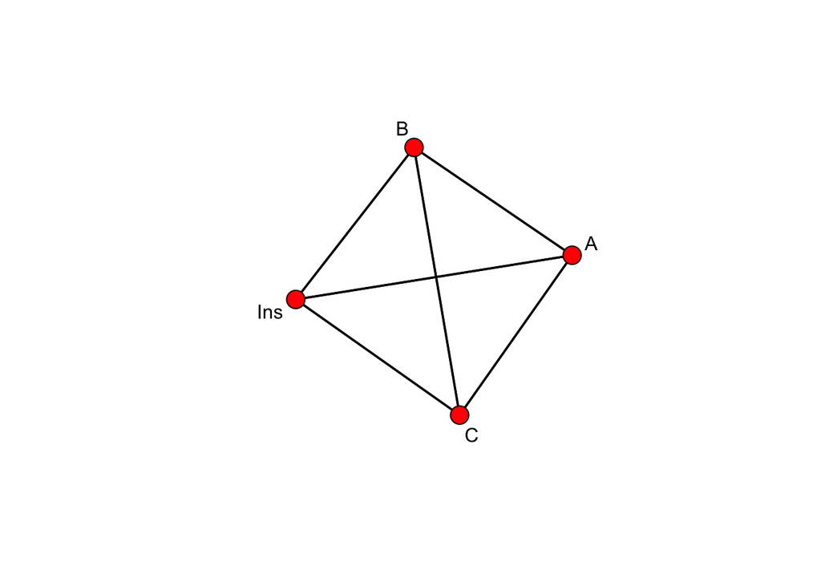

```r
#convert igraph to matrix
one_mode_mat02=as.matrix(get.adjacency(one_mode_graph))
# then we can use the previous method to create graphs
gplot(one_mode_mat02,gmode = "graph", usearrows = F, displaylabels = T)
```

### node-level and network-level measures

```r
# use sna package to calculate node-level centralities
node.centrality<-function(x){
           require(sna)
           central.nodes<-cbind(degree(x,cmode="indegree"), degree(x,cmode="outdegree"), betweenness(x,rescale=T),
                                closeness(x,cmode="directed",rescale=T))
           colnames(central.nodes)<-c("indegree","outdegree","betweenness","closeness")
           rownames(central.nodes)<-x%v%"vertex.names"


           list(central.nodes)
         }


# use igraph to calculate network-level measures
network.measure<-function(x){
      require(igraph)
      graph.measure<-cbind(as.numeric(length(V(x))),
                        as.numeric(length(E(x))),
                        as.numeric(diameter(x)),
                        as.numeric(graph.density(x)),
                        as.numeric(reciprocity(x)),
                        as.numeric(transitivity(x)),
                        as.numeric(average.path.length(x, unconnected=FALSE)), # important
                        as.numeric(mean(graph.strength(x))))

                        colnames(graph.measure)<-c("nodes","edges","diameter",
                              "density","reciprocity","transitivity",
                              "average path length","average weighted degree")
                        rownames(graph.measure)<-"x"
                        list(graph.measure)
}
```

#### grouping

```r
require(dplyr)
```

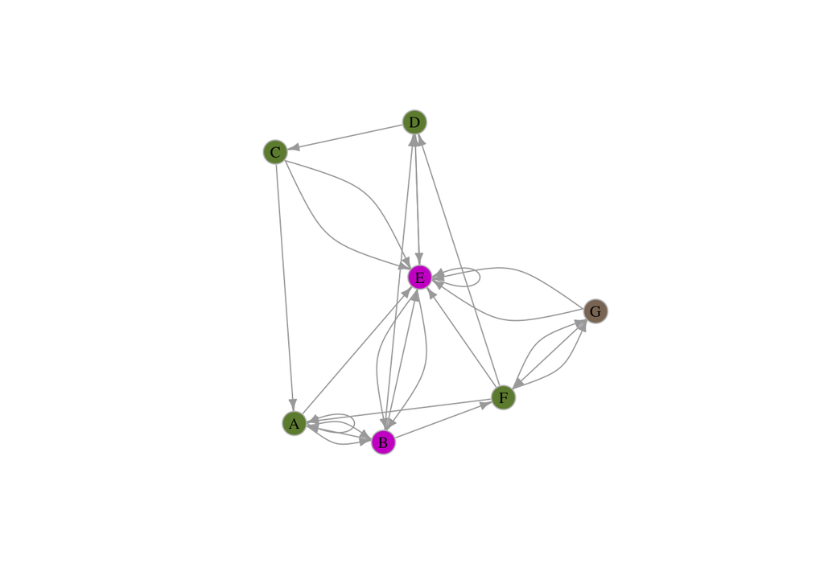

```r
require(igraph)
setwd("/Users/lt/Desktop")
sna_test=read.csv("sna_test.csv", head=TRUE)
sna_test1<-sna_test %>% mutate (group=ifelse(id1 %in% c("A","C","D"), "group 1",
                                  ifelse(id1 %in% c("B","E"),"group 2","group 3")))
sna_test2 <- sna_test1 %>% mutate(color=ifelse(group=="group 1","darkolivegreen4",
                                        ifelse(group=="group 2","magenta3","peachpuff4")))

sna_edges<-sna_test2 %>% select(id1,id2)

sna_graph <- graph_from_data_frame(sna_edges, directed = TRUE)

plot(sna_graph,
     vertex.label = sna_graph$id1,
     vertex.color = sna_test2$color,
     vertex.frame.color = "gray",
     vertex.label.color = "black",
     vertex.label.cex = 0.8,
     edge.arrow.size = 0.5)
```

### summary

There are basically two formats for save network data: adjacency matrix (wide-format) and edgelist (long-format). We can use reshape2 package (http://seananderson.ca/2013/10/19/reshape.html) to convert them mutually. Then we can use sna or igraph packages to plot and calculate node-level and network-level measures. It is useful to master both packages, converting them freely and applying to achieve different purposes.